# SVM project - TESLA

Jose Muralles

9/29/2019

# 1 Introduction

This is an implementation of a support vector machine designed to identify short-term stock price changes, based on previous stock parameters: open, low, high, close, volume. This might be useful for day trades

## 1.1 Stock selected for this exercise:

I saw lots of daily activity, so I was sure I could make lots of money. See the following graph

picture of the stock price

[figure not shown]

## 1.2 get data:

```r
TESLAdata = read.csv('TESLAtrimmed.csv')
View(TESLAdata)
```

Names of the variables in the data set: price.open, price.high, price.low, price.close, volume, price.adjusted, ref.date’ ticker’ ret.adjusted.prices, ret.closing.prices’ pctChange. changeCategory

## 1.3 set up data frame

```r
    TESLAdataFrame = data.frame(open=TESLAdata$price.open,        high=TESLAdata$price.high,  low=TESLAdata$price.low, close=TESLAdata$price.close,volume= TESLAdata$volume/10000,
      change = TESLAdata$changeCategory )

# look at top and bottom..
head(TESLAdataFrame)
```

```
##     open   high    low  close  volume change
## 1 269.82 273.35 254.49 267.53 1884.44      U
## 2 252.78 288.37 252.00 286.94 1989.67      U
## 3 289.34 306.26 288.20 305.72 1912.11      D
## 4 301.00 309.28 295.50 299.30 1352.03      E
## 5 300.37 309.50 289.21 289.66 1024.98      E
## 6 298.97 307.10 293.68 304.70 1098.98      D
```

```r
tail(TESLAdataFrame)
```

```
##       open   high    low  close volume change
## 366 246.96 248.45 244.87 245.20 531.31      E
## 367 246.00 247.43 241.17 242.81 472.81      E
## 368 242.47 245.60 240.37 244.79 386.54      D
## 369 245.00 248.17 242.37 243.49 417.02      D
## 370 246.00 247.94 244.84 246.60 479.58      E
## 371 246.49 246.95 238.16 240.62 635.30      E
```

```r
remove(TESLAdata)
```

```r
levels(TESLAdataFrame$change)
```

```
## [1] "D" "E" "U"
```

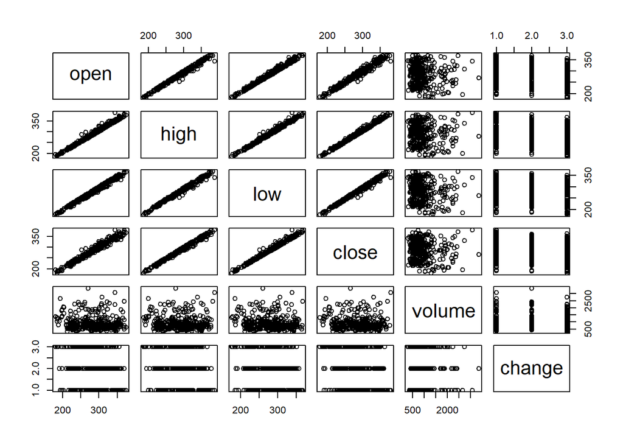

```r
plot(TESLAdataFrame)
```

## 1.4 classification model, categorical response

### 1.4.1 traditional interface:

```r
x <- subset(TESLAdataFrame[1:366,], select = -change)
y <- TESLAdataFrame[1:366,]$change
model1 <- svm(x, y)

#model1 is all the data
print(model1)
```

```
##
## Call:
## svm.default(x = x, y = y)
##
##
## Parameters:
##    SVM-Type:  C-classification
##  SVM-Kernel:  radial
##        cost:  1
##
## Number of Support Vectors:  360
```

```r
summary(model1)
```

```
##
## Call:
## svm.default(x = x, y = y)
##
##
## Parameters:
##    SVM-Type:  C-classification
##  SVM-Kernel:  radial
##        cost:  1
##
## Number of Support Vectors:  360
##
##  ( 112 121 127 )
##
##
## Number of Classes:  3
##
## Levels:
##  D E U
```

## 1.5 how well did the model fit?

```r
pred <- predict(model1, x)

# Check accuracy:
table(pred, y)
```

```
##     y
## pred  D  E  U
##    D 39 28 12
##    E 41 43 35
##    U 43 56 69
```

## 1.6 decision values

```r
# compute decision values and probabilities:
pred <- predict(model1, x, decision.values = TRUE)
attr(pred, "decision.values")[1:6,]
```

```
##           U/D        U/E        D/E
## 1  1.23489701  0.8620527 -1.0688984
## 2  1.17051162  1.0001598 -0.8677080
## 3  0.90987610  0.9883643 -0.8202871
## 4  0.01522663  0.0769499 -0.9330958
## 5 -0.15389679 -0.2600741 -0.8829459
## 6 -0.34995455 -0.3244475 -0.8024698
```

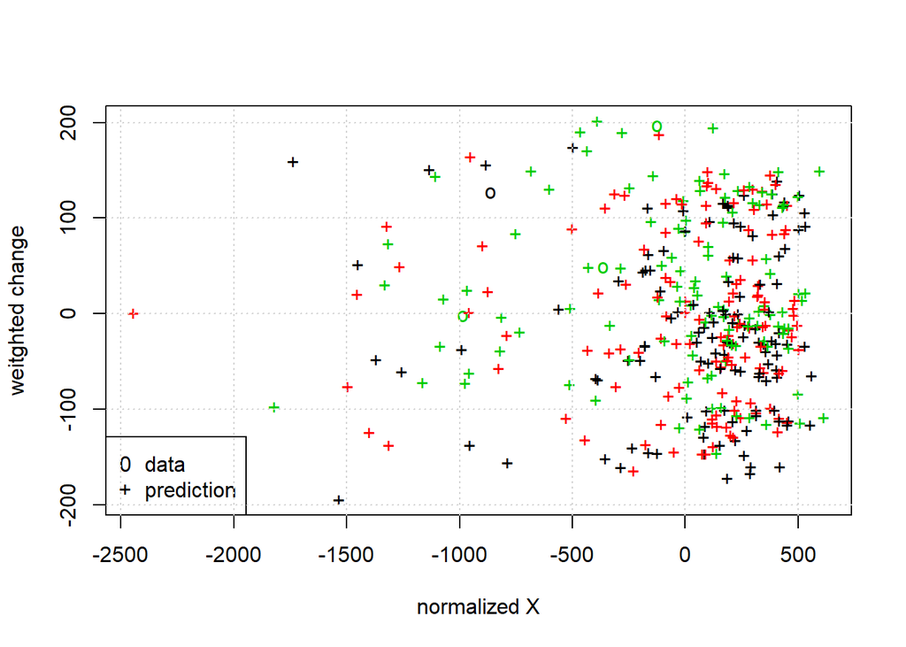

```r
# visualize (classes by color, SV by crosses):
plot(cmdscale(dist(TESLAdataFrame[,-6])),
     col = as.integer(TESLAdataFrame[,6]),xlab="normalized X", ylab = "weitghted change",
     pch = c("o","+")[1:150 %in% model1$index + 1])
legend('bottomleft',c('data','prediction'),pch=c('0','+'))
grid()
```

# 2 train and test sets:

```r
pctTrain=0.70  # use about 70% of the data
nObs = length(x[,1])
nObs = 366
nTrain = round(pctTrain*nObs,0)

# next line take data in order
#TrainSetIndex = 1:nTrain

# These lines take a random sample
scramble = sample(1:nObs)
TrainSetIndex = scramble[1:nTrain]
TestSetIndex = scramble[(nTrain+1):nObs]
```

## 2.1 set up training set, test set

```r
# first the training set

TESLAdataFrame1 = TESLAdataFrame[1:366,]

XtrainSet = TESLAdataFrame1[TrainSetIndex,-6]
YtrainSet = TESLAdataFrame1$change[TrainSetIndex]
```

## 2.2 get the model from training set..

This is model2

```r
model2 <- svm(XtrainSet, YtrainSet)

print(model2)
```

```
##
## Call:
## svm.default(x = XtrainSet, y = YtrainSet)
##
##
## Parameters:
##    SVM-Type:  C-classification
##  SVM-Kernel:  radial
##        cost:  1
##
## Number of Support Vectors:  252
```

```r
summary(model2)
```

```
##
## Call:
## svm.default(x = XtrainSet, y = YtrainSet)
##
##
## Parameters:
##    SVM-Type:  C-classification
##  SVM-Kernel:  radial
##        cost:  1
##
## Number of Support Vectors:  252
##
##  ( 82 83 87 )
##
##
## Number of Classes:  3
##
## Levels:
##  D E U
```

## 2.3 now the test set..

```r
XtestSet = TESLAdataFrame1[(TestSetIndex),-6]
YtestSet = TESLAdataFrame1$change[TestSetIndex]
```

## 2.4 and evaluate with the test data

```r
pred2 <- predict(model2, XtestSet)
# And the accuracy..

table(pred2, YtestSet)
```

```
##      YtestSet
## pred2  D  E  U
##     D 13  9  6
##     E  7  3  2
##     U 21 28 21
```

## 2.5 tune

```r
stockTuned <- tune.svm(XtrainSet, YtrainSet, gamma = 2^(-2:1), cost = 2^(1:4))

summary(stockTuned)
```

```
##
## Parameter tuning of 'svm':
##
## - sampling method: 10-fold cross validation
##
## - best parameters:
##  gamma cost
##      1   16
##
## - best performance: 0.6292308
##
## - Detailed performance results:
##    gamma cost     error dispersion
## 1   0.25    2 0.6561538 0.10605160
## 2   0.50    2 0.6530769 0.13695908
## 3   1.00    2 0.6604615 0.06176050
## 4   2.00    2 0.6873846 0.06418169
## 5   0.25    4 0.6527692 0.11392478
## 6   0.50    4 0.6647692 0.09126318
## 7   1.00    4 0.6761538 0.08674780
## 8   2.00    4 0.6604615 0.05618627
## 9   0.25    8 0.6609231 0.15435676
## 10  0.50    8 0.6450769 0.08191030
## 11  1.00    8 0.6601538 0.08825118
## 12  2.00    8 0.6407692 0.09124531
## 13  0.25   16 0.6607692 0.13394191
## 14  0.50   16 0.6526154 0.07078707
## 15  1.00   16 0.6292308 0.08777774
## 16  2.00   16 0.6364615 0.10884137
```

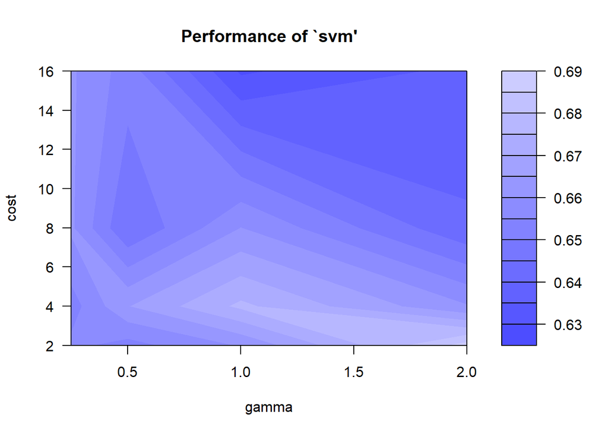

```r
plot(stockTuned)
```

```r
print(paste('best parameters: gamma=',stockTuned$best.parameters[1], ', cost=', stockTuned$best.parameters[2]))
```

```
## [1] "best parameters: gamma= 1 , cost= 16"
```

```r
#use optimized parameters...
model3 <- svm(XtrainSet, YtrainSet, gamma=as.numeric(stockTuned$best.parameters[1]), cost=as.numeric(stockTuned$best.parameters[2] ))

print(model3)
```

```
##
## Call:
## svm.default(x = XtrainSet, y = YtrainSet, gamma = as.numeric(stockTuned$best.parameters[1]),
##     cost = as.numeric(stockTuned$best.parameters[2]))
##
##
## Parameters:
##    SVM-Type:  C-classification
##  SVM-Kernel:  radial
##        cost:  16
##
## Number of Support Vectors:  241
```

```r
summary(model3)
```

```
##
## Call:
## svm.default(x = XtrainSet, y = YtrainSet, gamma = as.numeric(stockTuned$best.parameters[1]),
##     cost = as.numeric(stockTuned$best.parameters[2]))
##
##
## Parameters:
##    SVM-Type:  C-classification
##  SVM-Kernel:  radial
##        cost:  16
##
## Number of Support Vectors:  241
##
##  ( 79 78 84 )
##
##
## Number of Classes:  3
##
## Levels:
##  D E U
```

```r
pred3 <- predict(model3, XtestSet)
# And the accuracy..

table(pred3, YtestSet)
```

```
##      YtestSet
## pred3  D  E  U
##     D 10  7  5
##     E 16 13 18
##     U 15 20  6
```

Now use the last 5 values to see how we do

```r
XtestSetFortheMoney = TESLAdataFrame[367:371,-6]
YtestSetFortheMoney  = TESLAdataFrame[367:371,6]

pred4 <- predict(model3, XtestSetFortheMoney)
# And the accuracy..
print(pred4)
```

```
## 367 368 369 370 371
##   D   D   D   D   D
## Levels: D E U
```

```r
#table(pred4, YtestSetFortheMoney)
```

The actual last 5 days were E D D E E

ROI = negative too much

```r
# compute decision values and probabilities:
pred <- predict(model3, XtestSet, decision.values = TRUE)
attr(pred, "decision.values")[1:6,]
```

```
##            D/U         D/E        U/E
## 237 -0.5099761  0.45490121  0.9255205
## 230 -0.4817474 -0.10083979  1.4474098
## 89  -0.4715504  0.06091419  0.4265914
## 135 -0.2351156 -1.07931472 -0.5766155
## 348 -0.8079875 -0.34852247  0.7591539
## 28   1.3173151  0.83805352 -1.0675502
```

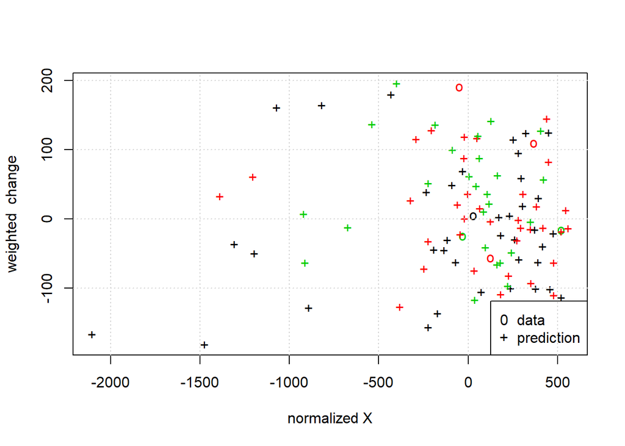

```r
# visualize (classes by color, SV by crosses):
plot(cmdscale(dist(XtestSet)),
     col = as.integer(YtestSet),xlab="normalized X", ylab = "weighted  change",
     pch = c("o","+")[1:150 %in% model3$index + 1])
legend('bottomright',c('data','prediction'),pch=c('0','+'))
grid()
```

# 3 SVM assignment

## 3.1 complete an rmarkdown file on the stock you selected.

You will turn in the URL for your github accout that has the repo for this assignment.

### 3.1.1 Identify the stock you use for this assignment.

Why did you choose this particular stock? Had lots of variability

### 3.1.2 Use this template to get the SVM:

1. Training and Test sets:
2. How well did the SVM do?

The SVM did not do well in predictions.

3. Tune the algorithm- i.e. find optimal gamma and cost values.

tuned it, found optimal gamma and cost values, didn’t seem to help

### 3.1.3 Evaluate SVM performance

1. Did you exmine using other than the ‘open’, ‘low’, ‘high’, ‘close’ prices and volume as predictors?
2. Use the SVM you developed to predict stock moves on 16 - 20 Sept. 2019. Compute the ROI assuming the SVM identifies an opportunity, (for example use around $1000 on each of the SVM predictions)

3. Would you put your own $$ in this SVM?
   You gotta be kidding me..